# ReproducibleResearchProject

Emily Daniels

5/7/2020

# REPRODUCIBLE RESEARCH PROJECT 1

## Introduction

This assignment makes use of data from a personal activity monitoring device. This device collects data at 5 minute intervals through out the day. The data consists of two months of data from an anonymous individual collected during the months of October and November, 2012 and include the number of steps taken in 5 minute intervals each day. The data is stored in a CSV file and there are 17,568 observations in the dataset.

#### Data with NAs

```r
    walkingNA <- read.csv2(unzip("C:\\Users\\emily.e.daniels\\Documents\\R\\Assignments\\Reproducible Research Project 1\\repdata_data_activity.zip", "activity.csv"),sep = ",", nrows = 17568, header = TRUE)
        walkingNA$date <- as.Date(walkingNA$date)
```

#### Data without NAs

```r
    walkingNONA <- na.omit(walkingNA)
        walkingNONA$date <- as.Date(walkingNONA$date)
```

### What is the mean total number of steps taken per day? {css.class}

- Calculate the total number of steps taken per day without NAs.

```r
    steptotal <- aggregate(walkingNONA$steps, by = list((substr(walkingNONA$date,1,15264))), sum)
        colnames(steptotal) <- c("Date", "Total Steps")
```

- Calculate and report the mean and median of the total number of steps taken each day.

```r
## Mean steps
        mean(steptotal$`Total Steps`)
```

```
## [1] 10766.19
```

```r
        # 10766.19
## Median steps
        median(steptotal$`Total Steps`)
```

```
## [1] 10765
```

```r
        #10765

steptotalNA <- aggregate(walkingNA$steps, by = list((substr(walkingNA$interval, 1, 17568))), mean) #na.rm =TRUE
          colnames(steptotalNA) <- c("interval", "steps")
```

```
+ The mean number of steps taken each day: **10766.19**
+ The median number of steps taken each day: **10765**
```

- Make a histogram of the total number of steps taken each day.

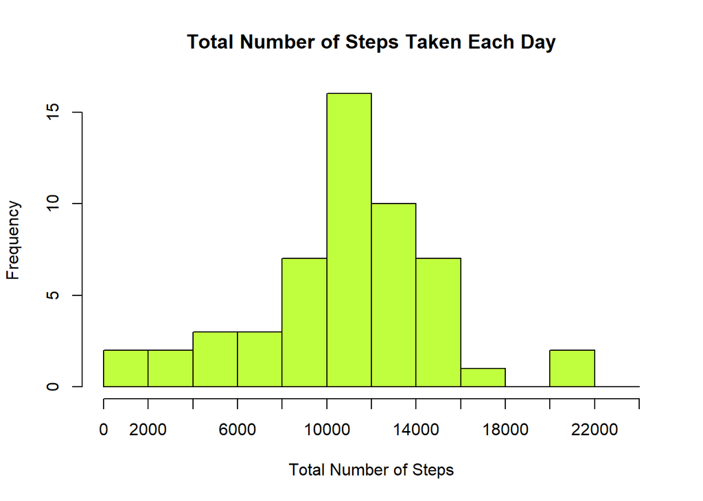

```r
data_histogram <- walkingNONA %>%
  mutate(date = factor(date)) %>%
  group_by(date) %>%
  summarize(steps = round(sum(steps),2))
plot.new()

hist(data_histogram$steps, breaks = seq(0, 25000, by = 2000), col = "olivedrab1", xlab = "Total Number of Steps", main = "Total Number of Steps Taken Each Day", xaxt ='n')
  axis(side=1, at=seq(0,25000, 2000), labels=seq(0,25000,2000))
```

### What is the Average Daily Activity Pattern? {css.class} * Make a time series plot ( type = “l”) of the 5 minute interval (x) and the average number of steps taken, averaged across all days (y).

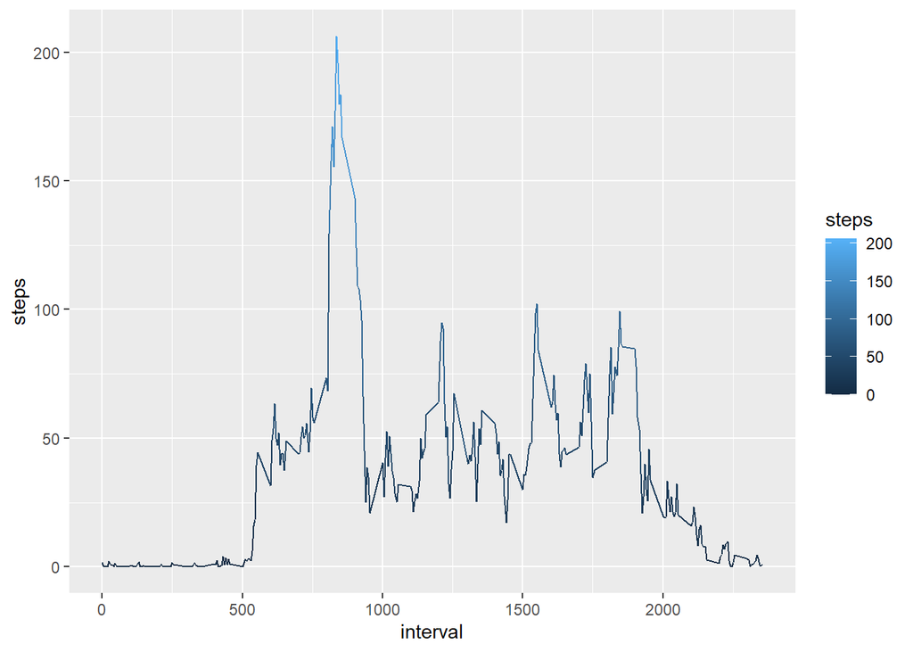

```r
# Total steps averaged by 5 minute time interval
data_line <- walkingNONA %>%
  mutate(date = factor(date)) %>%
  group_by(interval) %>%
  summarize(steps = round(mean(steps),2))

dat <- ggplot(data_line, aes(interval, steps, color = steps)) + geom_line()
dat
```

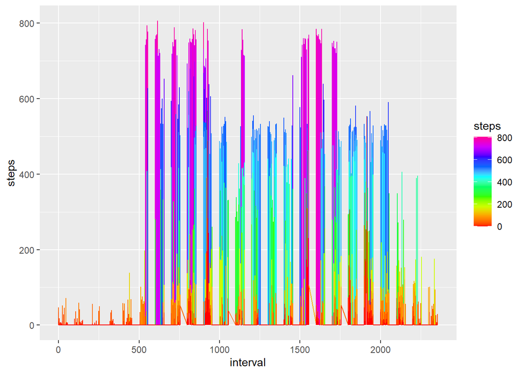

```r
# Total steps averaged by time interval and date
data_line1 <- walkingNONA %>%
  mutate(date = factor(date)) %>%
  group_by(interval, date) %>%
  summarize(steps = round(mean(steps),2))

line <- ggplot(data_line1, aes(interval, steps, color = steps)) + geom_line() + scale_color_gradientn(colors=rainbow(10))
line
```

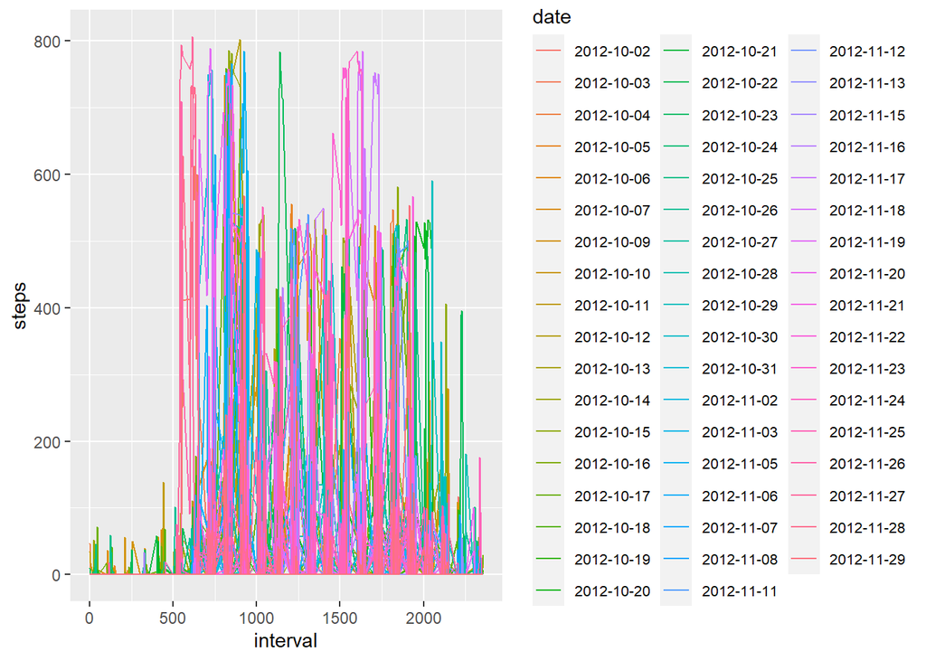

```r
# Total steps by time interval with dated legend
data_line2 <- walkingNONA %>%
  mutate(date = factor(date)) %>%
  group_by(interval, date) %>%
  summarize(steps = round(mean(steps),2))

line2 <- ggplot(data_line2, aes(interval, steps, color = date)) + geom_line()
#+ scale_color_gradientn(colors=rainbow(10))
line2 + theme(legend.position = "right", legend.text = element_text(size = 8), legend.box="horizontal" )
```

I decided to explore the time series data and play around with displaying the data in different ways.  
* **Which 5 minute interval, on average across all the says in the dataset, contains the maximum number of steps?**

```r
maxsteps <-  data_line[which.max(data_line$steps), ]$interval
      head(maxsteps) #835
```

```
## [1] 835
```

[output not shown]

### Imputing missing values {css.class}

*Imputation* is the process of replacing missing data with substituted values. The presence of missing data may introduce bias into some calculations or data summaries. Up until now, we’ve been working with data containing NO NA values.  
* Calculate and report the total number of missing values in the dataset (**How many rows of NA values are there?**)

```r
    NAsteps <- sum(is.na(walkingNA$steps))
    NAsteps #2304 NA's in steps
```

```
## [1] 2304
```

```r
    stNA <- aggregate(walkingNA$steps, by = list((substr(walkingNA$interval,1,15264))), mean)
        colnames(stNA) <- c("interval", "steps")
        head(stNA)
```

```
##   interval steps
## 1        0    NA
## 2       10    NA
## 3      100    NA
## 4     1000    NA
## 5     1005    NA
## 6     1010    NA
```

```r
meansteps <- mean(stNA$steps)
        class(meansteps)
```

```
## [1] "numeric"
```

```r
        head(meansteps)
```

```
## [1] NA
```

- Create a new dataset that is equal to the original dataset with the missing data filled in

```r
    newwalk <- walkingNA
# For the cases of newwalk with NAs in the steps column, apply meansteps to fill the NAs
    newwalk[NAsteps, 1] <- meansteps
        head(newwalk)
```

```
##   steps       date interval
## 1    NA 2012-10-01        0
## 2    NA 2012-10-01        5
## 3    NA 2012-10-01       10
## 4    NA 2012-10-01       15
## 5    NA 2012-10-01       20
## 6    NA 2012-10-01       25
```

- Make a histogram of the total number of steps taken each day

```r
    stepsdaily <- aggregate(steps~date, newwalk, sum)
        head(stepsdaily$steps)
```

```
## [1]   126 11352 12116 13294 15420 11015
```

[figure not shown]

```r
  hist(stepsdaily$steps, main = "Number of Steps Taken Daily- with imputed values",
     xlab = "Steps", col = wes_palette("GrandBudapest2", 5, type = "continuous"))
```

* Calculate and report the mean and median total number of steps taken per day

```r
# Mean steps
    mean(stepsdaily$steps)
```

```
## [1] 10766.19
```

```r
    #10766.19

# Median steps
     median(stepsdaily$steps)
```

```
## [1] 10765
```

```r
     #10765
```

[output not shown]

### Are there differences in activity patterns between the weekdays and weekends? {css.class}

- Create a new variable with weekday and weekend levels

```r
#Create a new factor variable in the dataset with two levels – “weekday” and “weekend” indicating whether a given date is a weekday or weekend day.
weekday <- weekdays(walkingNONA$date, abbreviate = TRUE)
    head(weekday)
```

```
## [1] "Tue" "Tue" "Tue" "Tue" "Tue" "Tue"
```

```r
# Separate out weekends
walkingNONA$date <- as.Date(walkingNONA$date)
walkingNONA$day <- weekdays(walkingNONA$date)
for (i in 1:nrow(walkingNONA)) {
    if (walkingNONA[i,]$day %in% c("Saturday","Sunday")) {
        walkingNONA[i,]$day<-"weekend"
    }
    else{
        walkingNONA[i,]$day<-"weekday"
    }
}

dailystep <- aggregate(walkingNONA$steps ~ walkingNONA$interval + walkingNONA$day, walkingNONA, mean)
      names(dailystep) <- c("interval", "day", "steps")
      head(dailystep)
```

```
##   interval     day     steps
## 1        0 weekday 2.3333333
## 2        5 weekday 0.4615385
## 3       10 weekday 0.1794872
## 4       15 weekday 0.2051282
## 5       20 weekday 0.1025641
## 6       25 weekday 1.5128205
```

- Make a line (type = “l”) panel plot of the 5 minute interval (x) and the average number of steps taken, averaged across all days (y), separated by weekday and weekend.

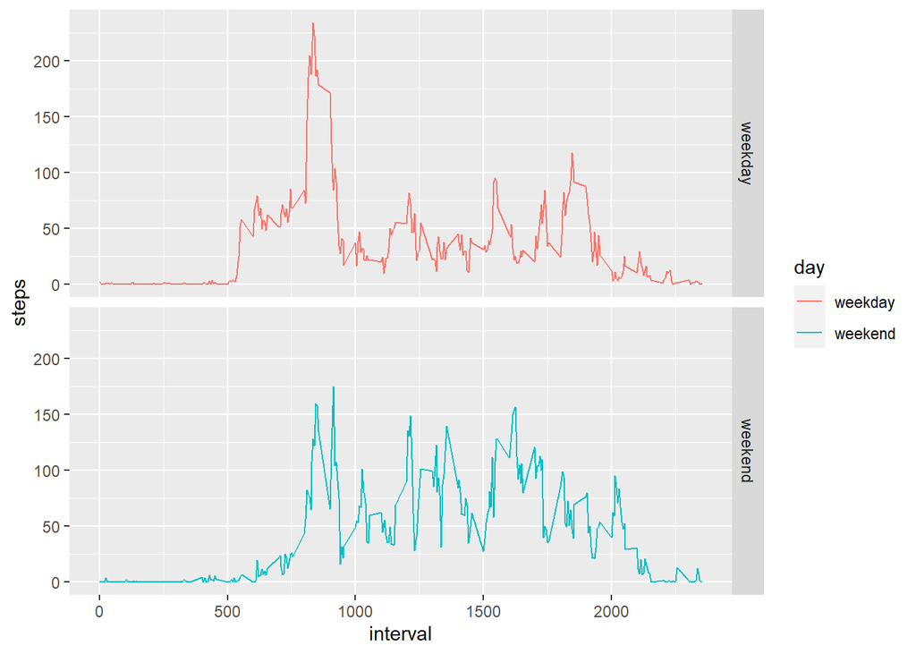

```r
    wkday <- ggplot(dailystep, aes(x = interval, y = steps, color = day, group = 1)) + geom_line()
      wkday + facet_grid(vars(day))
```